# Map of New Zealand

*Raynaldi Pratama*

12/02/2021

**Acknowledgement:** This portfolio was re-worked by the author using a different dataset. The original source code can be found in [Introduction to GIS: Manipulating and Mapping Geospatial Data in R](https://atlan.com/courses/introduction-to-gis-r/).

**Library setup:**

```r
# Working with table
library(kableExtra)

# Data wrangling
library(dplyr)

# Spatial analysis
library(sf)
library(raster)
library(spData)

# Additional packages
library(tmap)
library(grid)
```

## Basic map of New Zealand

The data we are going to use for this project is available in **`spData`** library. Thanks to **Robin Lovelace and his colleagues** for providing, not only a brief intro to **`spData`** library but also a great learning source: [Geocomputation with R](https://geocompr.robinlovelace.net/). In this case, a set of geo-information corresponding to New Zealand, collected in **`nz`** dataset, is chosen.

### Load the data

```r
kbl(nz) %>%
  kable_paper() %>%
  scroll_box(width = "100%", height = "300px")
```

| Name | Island | Land_area | Population | Median_income | Sex_ratio | geom |
| --- | --- | --- | --- | --- | --- | --- |
| Northland | North | 12500.5611 | 175500 | 23400 | 0.9424532 | MULTIPOLYGON (((1745493 600… |
| Auckland | North | 4941.5726 | 1657200 | 29600 | 0.9442858 | MULTIPOLYGON (((1803822 590… |
| Waikato | North | 23900.0364 | 460100 | 27900 | 0.9520500 | MULTIPOLYGON (((1860345 585… |
| Bay of Plenty | North | 12071.1447 | 299900 | 26200 | 0.9280391 | MULTIPOLYGON (((2049387 583… |
| Gisborne | North | 8385.8266 | 48500 | 24400 | 0.9349734 | MULTIPOLYGON (((2024489 567… |
| Hawke’s Bay | North | 14137.5244 | 164000 | 26100 | 0.9238375 | MULTIPOLYGON (((2024489 567… |
| Taranaki | North | 7254.4804 | 118000 | 29100 | 0.9569363 | MULTIPOLYGON (((1740438 571… |
| Manawatu-Wanganui | North | 22220.6084 | 234500 | 25000 | 0.9387734 | MULTIPOLYGON (((1866732 566… |
| Wellington | North | 8048.5528 | 513900 | 32700 | 0.9335524 | MULTIPOLYGON (((1881590 548… |
| West Coast | South | 23245.4559 | 32400 | 26900 | 1.0139072 | MULTIPOLYGON (((1557042 531… |
| Canterbury | South | 44504.4991 | 612000 | 30100 | 0.9753265 | MULTIPOLYGON (((1686902 535… |
| Otago | South | 31186.3092 | 224200 | 26300 | 0.9511694 | MULTIPOLYGON (((1335205 512… |
| Southland | South | 31196.0604 | 98300 | 29500 | 0.9785069 | MULTIPOLYGON (((1229078 506… |
| Tasman | South | 9615.9760 | 51100 | 25700 | 0.9718981 | MULTIPOLYGON (((1616643 542… |
| Nelson | South | 422.1952 | 51400 | 27200 | 0.9259674 | MULTIPOLYGON (((1624866 541… |
| Marlborough | South | 10457.7455 | 46200 | 27900 | 0.9577922 | MULTIPOLYGON (((1686902 535… |

### Plot the data

To plot the data, we will take advantage of the available thematic map **`tmap`** library. Another good source to explore the use of **`tmap`** can also be found [here](http://zevross.com/blog/2018/10/02/creating-beautiful-demographic-maps-in-r-with-the-tidycensus-and-tmap-packages/). Referring to the data structure shown before, we will consider the **`nz$Land_area`** data for the basic map of New Zealand.

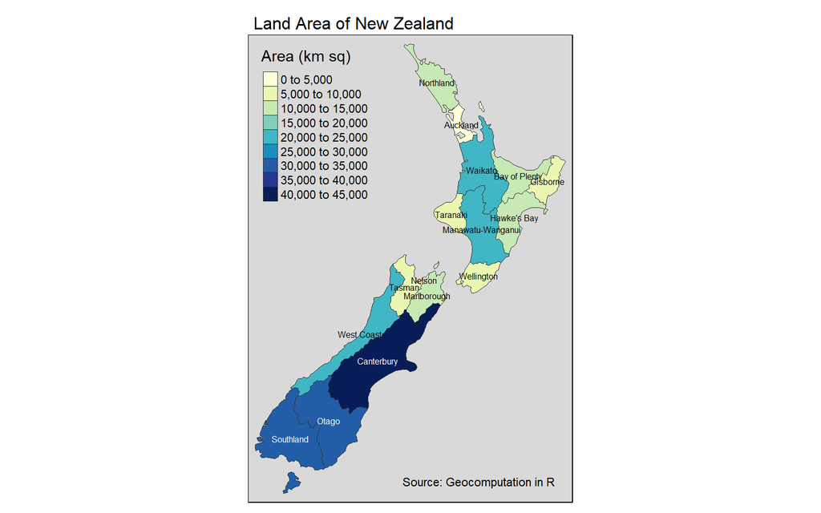

```r
basic_map_nz <- tm_shape(nz) +
  tm_fill(
    col = "Land_area",
    title = expression("Area (km sq)"),
    n = 10, palette = "YlGnBu"
  ) +
  tm_borders(lwd = 0.5) +
  tm_text("Name", size = 0.5) +
  tm_style("grey") +
  tm_layout(
    main.title = "Land Area of New Zealand",
    main.title.position = c("left"),
    main.title.size = 1,
    legend.position = c("left", "top"),
    legend.width = 0.5
  ) +
  tm_credits(
    "Source: Geocomputation in R",
    position = c("right", "bottom")
  )

basic_map_nz
```

## Population and sex ratio in NZ

### Plot the population data

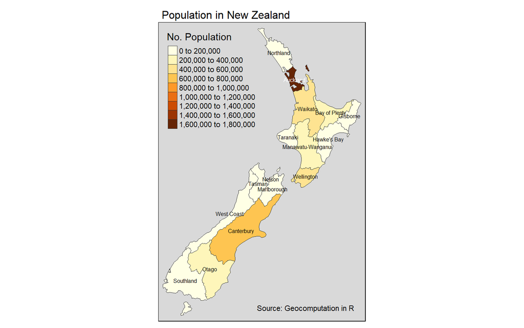

```r
population_nz <- tm_shape(nz) +
  tm_fill(
    col = "Population",
    title = "No. Population",
    n = 10, palette = "YlOrBr"
  ) +
  tm_borders(lwd = 0.5) +
  tm_text("Name", size = 0.5) +
  tm_style("grey") +
  tm_layout(
    main.title = "Population in New Zealand",
    main.title.position = c("left"),
    main.title.size = 1,
    legend.position = c("left", "top"),
    legend.width = 0.5
  ) +
  tm_credits(
    "Source: Geocomputation in R",
    position = c("right", "bottom")
  )

population_nz
```

### Plot the sex ratio data

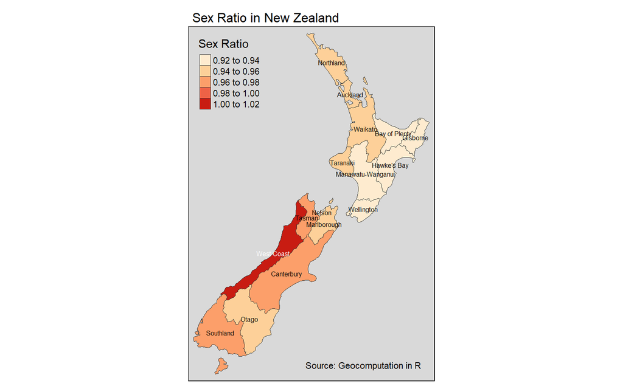

```r
sex_ratio_nz <- tm_shape(nz) +
  tm_fill(
    col = "Sex_ratio",
    title = "Sex Ratio",
    palette = "OrRd"
  ) +
  tm_borders(lwd = 0.5) +
  tm_text("Name", size = 0.5) +
  tm_style("grey") +
  tm_layout(
    main.title = "Sex Ratio in New Zealand",
    main.title.position = c("left"),
    main.title.size = 1,
    legend.position = c("left", "top"),
    legend.width = 0.5
  ) +
  tm_credits(
    "Source: Geocomputation in R",
    position = c("right", "bottom")
  )

sex_ratio_nz
```

### Line up multiple **`tmap`** objects

To get a general picture of the comparison between population and sex ratio in New Zealand, it is a good idea to have both maps plotted side by side. In **`tmap`** library, this can be done by calling out **`tmap_arrange()`** and passing in the designated map(s) as an argument.

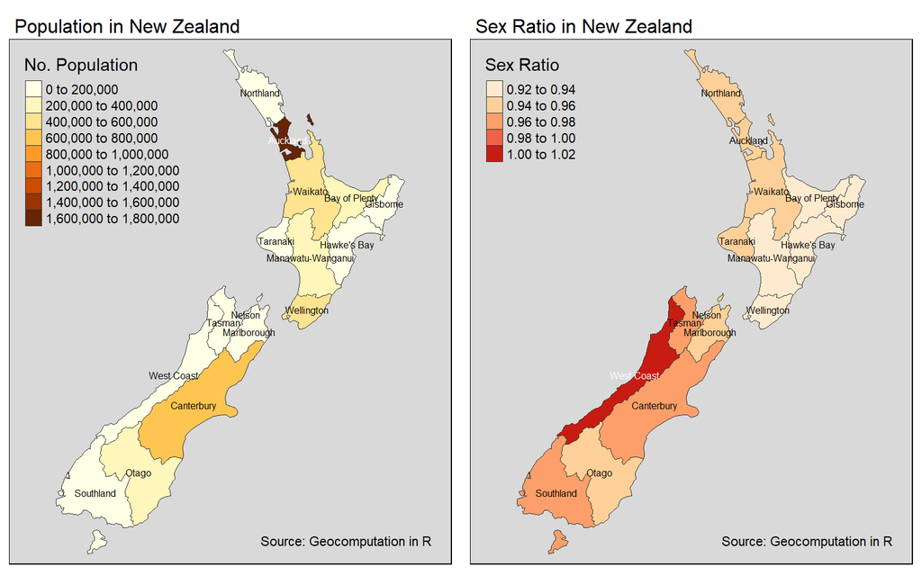

```r
tmap_arrange(population_nz, sex_ratio_nz)
```

## Median income in NZ (South)

### Plot the median income data

According to **`nz`** dataset, we can plot the median income data of New Zealanders as a map. However, it might be more interesting to see how we can visualize the data, not for a full country, but, based on the **`nz$Island`** division: North and South. Now, suppose we are interested in the Southern part of New Zealand, then we should filter out all the data corresponding to the North New Zealand.

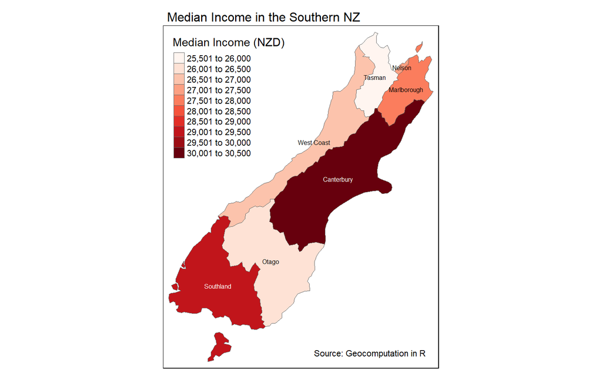

```r
south_median_income <- nz %>%
  filter(Island == "South") %>%
  tm_shape() +
  tm_fill(
    col = "Median_income",
    title = "Median Income (NZD)",
    n = 10, palette = "Reds"
  ) +
  tm_borders(lwd = 0.5) +
  tm_text("Name", size = 0.5) +
  tm_layout(
    main.title = "Median Income in the Southern NZ",
    main.title.position = c("left"),
    main.title.size = 1,
    legend.position = c("left", "top"),
    legend.width = 0.5
  ) +
  tm_credits(
    "Source: Geocomputation in R",
    position = c("right", "bottom")
  )

south_median_income
```

### Add the inset map feature

In general, the inset figure is not always essential to our map. However, in this specific case, it can be more informative to put the inset map feature as we want to show which part of our area of interest. The inset map below indicates the Southern New Zealand area in red colour. It should be noted that to get a proportional size and position of the inset, trials and errors should be performed accordingly.

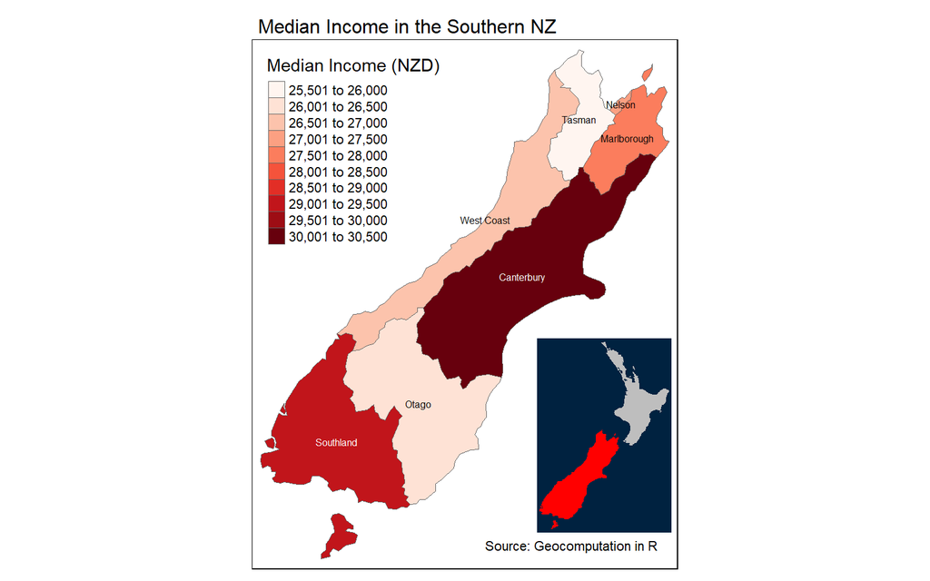

```r
inset <- nz %>%
  group_by(Island) %>%
  mutate(Southern_NZ = ifelse(Island == "South", TRUE, FALSE)) %>%
  tm_shape() +
  tm_fill(col = "Southern_NZ", palette = c("grey", "red")) +
  tm_style("cobalt") +
  tm_legend(show = FALSE)

south_median_income

print(inset, vp = viewport(0.65, 0.25, width = 0.25, height = 0.35))
```

## Animated and interactive map

```r
nz_animation <- tm_shape(nz) +
  tm_borders(lwd = 1.5) +
  tm_fill(
    col = "Median_income",
    title = "Median Income (NZD)",
    palette = "OrRd"
  ) +
  tm_facets(
    by = "Island", along = "Name", free.coords = FALSE
  )
```

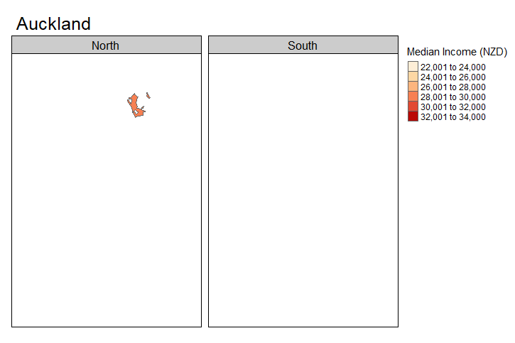

```r
# Write .gif file
tmap_animation(nz_animation, filename = "nz_animation.gif", delay = 150)
```

### Interactive map

```r
tmap_mode(mode = "view") # mode = "view" for interactive map
```

```
## tmap mode set to interactive viewing
```

```r
basic_map_nz
```

[interactive chart not shown]